# 20181103-Schedule_Run_Task_Using_Crontab_In_CentOS7

# 20181103-Schedule_Run_Task_Using_Crontab_In_CentOS7

## 零、crond简介与Linux下的任务调度

### crond简介

crontab命令常见于Unix和类Unix的操作系统之中，用于设置周期性被执行的指令。通过crontab 命令，我们可以在固定的间隔时间执行指定的系统指令或 shell script脚本。

时间间隔的单位可以是分钟、小时、日、月、周及以上的任意组合。这个命令非常设合周期性的日志分析或数据备份等工作。

该命令从标准输入设备读取指令，并将其存放于“crontab”文件中（是“cron table”的简写），以供之后读取和执行。

该词来源于希腊语 chronos(χρνο)，原意是时间。

通常，crontab储存的指令被守护进程激活， crond常常在后台运行，每一分钟检查是否有预定的作业需要执行。这类作业一般称为cron jobs。

linux 系统则是由 cron (crond) 这个系统服务来控制的。Linux 系统上面原本就有非常多的计划性工作，因此这个系统服务是默认启动的。另外, 由于使用者自己也可以设置计划任务，所以， Linux 系统也提供了使用者控制计划任务的命令 :crontab 命令。

> 简单点说：cron就是和闹钟的概念类似，就是定时执行。

crond 是linux下用来周期性的执行某种任务或等待处理某些事件的一个守护进程，与windows下的计划任务类似，当安装完成操作系统后，默认会安装此服务 工具，并且会自动启动crond进程，crond进程每分钟会定期检查是否有要执行的任务，如果有要执行的任务，则自动执行该任务。

### Linux下的任务调度

Linux下的任务调度分为两类，系统任务调度和用户任务调度。

#### 系统任务调度：

系统周期性所要执行的工作，比如写缓存数据到硬盘、日志清理等。在/etc目录下有一个crontab文件，这个就是系统任务调度的配置文件。`cat /etc/crontab` /etc/crontab文件包括下面几行：

```bash
SHELL=/bin/bash
PATH=/sbin:/bin:/usr/sbin:/usr/bin
MAILTO=
HOME=/

$ # run-parts
51 * * * * root run-parts /etc/cron.hourly
24 7 * * * root run-parts /etc/cron.daily
22 4 * * 0 root run-parts /etc/cron.weekly
42 4 1 * * root run-parts /etc/cron.monthly
```

/etc/crontab in CentOS7 @ 2018-11-03

```bash
# /etc/crontab in CentOS7 @ 2018-11-03
SHELL=/bin/bash
PATH=/sbin:/bin:/usr/sbin:/usr/bin
MAILTO=root

# For details see man 4 crontabs

# Example of job definition:
# .---------------- minute (0 - 59)
# |  .------------- hour (0 - 23)
# |  |  .---------- day of month (1 - 31)
# |  |  |  .------- month (1 - 12) OR jan,feb,mar,apr ...
# |  |  |  |  .---- day of week (0 - 6) (Sunday=0 or 7) OR sun,mon,tue,wed,thu,fri,sat
# |  |  |  |  |
# *  *  *  *  * user-name  command to be executed
```

前四行是用来配置crond任务运行的环境变量：

第一行SHELL变量指定了系统要使用哪个shell，这里是bash，

第二行PATH变量指定了系统执行 命令的路径，

第三行MAILTO变量指定了crond的任务执行信息将通过电子邮件发送给root用户，如果MAILTO变量的值为空，则表示不发送任务 执行信息给用户，

第四行的HOME变量指定了在执行命令或者脚本时使用的主目录。

第六至九行表示的含义将在下个小节详细讲述。这里不在多说。

#### 用户任务调度：

用户定期要执行的工作，比如用户数据备份、定时邮件提醒等。

用户可以使用 crontab 工具来定制自己的计划任务。

所有用户定义的crontab 文件都被保存在 */var/spool/cron*目录中。其文件名与用户名一致。

## 一、crontab文件的含义-基本格式：

### crontab的配置文件–使用者权限文件

crontab 的配置文件

| 文件 | 说明 |
| --- | --- |
| /etc/crontab | 全局配置文件 |
| /etc/cron.d | 这个目录用来存放任何要执行的crontab文件或脚本 |
| /etc/cron.deny | 该文件中所列用户不允许使用crontab命令 |
| /etc/cron.allow | 该文件中所列用户允许使用crontab命令 |
| /var/spool/cron/ | 所有用户crontab文件存放的目录,以用户名命名，比如你是root 用户，那么当你添加任务是，就会在该路径下有一个root文件 |
| /etc/cron.deny | 该文件中所列用户不允许使用crontab命令 |
| /var/log/cron | crontab 的日志文件 |

### crontab文件六段式格式解读

用户所建立的crontab文件中，每一行都代表一项任务，每行的每个字段代表一项设置，它的格式共分为六个字段，前五段是时间设定段，第六段是要执行的命令段，格式如下：

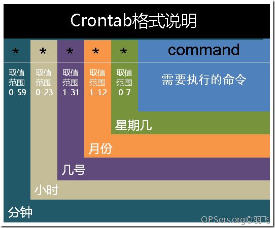

Crontab_Format.png

```bash
*　　*　　*　　*　　*　　command
# M H D m w cmd
# minute hour day month week command
# 分　  时　  日　 月　 周 　命令
# 分钟(0-59)　小时(0-23)　日期(1-31)　月份(1-12)　星期(0-6,0代表星期天)　 命令

# 第1列M/minute，表示分钟0～59之间的任何整数 每分钟用*或者 */1表示

# 第2列H/hour,表示小时0～23之间的任何整数（0表示0点）

# 第3列D/day,表示日期1～31之间的任何整数

# 第4列m/month,表示月份1～12 之间的任何整数

# 第5列w/week,表示星期0～6之间的任何整数（0表示星期天）

# 第6列command, 表示要运行/执行的命令/程序,可以是系统命令，也可以是自己编写的脚本文件。这个shell只有USER,HOME,SHELL这三个环境变量


## 解读crontab 2
f1 f2 f3 f4 f5 program
minute hour day month week command
# M H D m w cmd
# For details see man 4 crontabs
# Example of job definition:
.------------------------ minute (0 - 59) 分钟
| .---------------------- hour (0 - 23) 小时
| | .-------------------- day of month (1 - 31) 日期
| | | .------------------ month (1 - 12) OR jan,feb,mar,apr ... 月份
| | | | .---------------- day of week (0 - 6) (Sunday=0 or 7) OR sun,mon,tue,wed,thu,fri,sat
| | | | | .------------- username 以哪个用户来执行
| | | | | | .------ command 要执行的命令，可以是系统命令，也可以是自己编写的脚本文件
| | | | | | |
* * * * * user-name command to be executed

其中 f1 是表示分钟，f2 表示小时，f3 表示一个月份中的第几日，f4 表示月份，f5 表示一个星期中的第几天。program 表示要执行的程序。
```

### crontab文件中特殊字符的使用

在crontab以上各个字段中，可以使用以下特殊字符：

- *表示任何时候都匹配
- “a,b,c” 表示a 或者 b 或者c 执行命令
- “a-b” 表示a到b 之间 执行命令
- “*/a" 表示每 a分钟(小时等) 执行一次

#### 星号（*）：

代表所有可能的值，例如month字段如果是星号，则表示在满足其它字段的制约条件后每月都执行该命令操作。

例：当 f1 为 * 时表示每分钟都要执行 program，f2 为 * 时表示每小时都要执行程序，其余类推

#### 逗号（,）：

可以用逗号隔开的值指定一个列表范围，例如，“1,2,5,7,8,9”

例：当 f1 为 a, b, c,… 时表示第 a, b, c,… 分钟要执行，f2 为 a, b, c,… 时表示第 a, b, c…个小时要执行，其余类推

#### 中杠（-）：

可以用整数之间的中杠表示一个整数范围，例如“2-6”表示“2,3,4,5,6”

例：当 f1 为 a-b 时表示从第 a 分钟到第 b 分钟这段时间内要执行，f2 为 a-b 时表示从第 a 到第 b 小时都要执行，其余类推

#### 正斜线（/）：

可以用正斜线指定时间的间隔频率，例如“0-23/2”表示每两小时执行一次。同时正斜线可以和星号一起使用，例如*/10，如果用在minute字段，表示每十分钟执行一次。

例：当 f1 为 */n 时表示每 n 分钟个时间间隔执行一次，f2 为 */n 表示每 n 小时个时间间隔执行一次，其余类推

使用者也可以将所有的设定先存放在档案 file 中，用 crontab file 的方式来设定时程表。

## 二、开启Crontab服务

### 检查是否安装crontab

下面的命令 如果显示 ‘no crontab for root’ 或者 显示当前的任务列表 或者 不报错 那说明已经安装，

```bash
# 检查是否安装:
crontab -l
```

### 安装crontab

```bash
yum install crontabs

# OR Use This
yum -y install vixie-cron crontabs
```

### 查看crontab服务状态

```bash
service crond status
```

### 开启crontab服务

```bash
service crond start

# Add schedule task
crontab -e

# 服务操作说明：
# 启动服务
/sbin/service crond start

# 关闭服务
/sbin/service crond stop

# 重启服务
/sbin/service crond restart

# 重新载入配置
/sbin/service crond reload

# 启动服务
/sbin/service crond status
```

### crontab服务加入开机自动启动

```bash
# 查看crontab服务是否已设置为开机启动，执行命令：
ntsysv

# 加入开机自动启动：
chkconfig –level 35 crond on

crontab -e
#命令可以在vi中编辑定期任务
# 如下面代码每一分钟向文本写入当前日期
# * * * * * date >> ~/log.txt
#    1
#    2

# 创建任务后，用 crontab -l 查看当前用户的任务列表
crontab -l
```

## 三、crontab命令详解

### 1．crontab命令格式

crontab [-u user] file

crontab [-u user] [ -e | -l | -r ]

### 2．crontab命令功能

通过crontab 命令，我们可以在固定的间隔时间执行指定的系统指令或 shell script脚本。时间间隔的单位可以是分钟、小时、日、月、周及以上的任意组合。这个命令非常设合周期性的日志分析或数据备份等工作。

### 3．crontab命令参数

crontab 是用来让使用者在固定时间或固定间隔执行程序之用。

换句话说，也就是类似使用者的时程表。

-u user 是指设定指定user 的时程表，这个前提是你必须要有其权限(比如说是root)才能够指定他人的时程表。

如果不使用 -u user 的话，就是表示设定自己的时程表。 所有使用者都有权限使用crontab，使用方式/命令参数如下

```bash
# 用指定的文件替代目前的crontab。
crontab file [-u user]

# 用标准输入替代目前的crontab.
crontab -[-u user]

# 列出用户目前的crontab.
crontab -1[user]

# 编辑用户目前的crontab.
crontab -e[user]

# 删除用户目前的crontab.
crontab -d[user]

# 指定crontab的目录。
crontab -c dir
```

#### crontab命令参数说明

crontab -e : 编辑某个用户的crontab文件内容。如果不指定用户，则表示编辑当前用户的crontab文件。执行文字编辑器来设定时程表，内定的文字编辑器是 VI，如果你想用别的文字编辑器，则请先设定 VISUAL 环境变数来指定使用那个文字编辑器(比如说 setenv VISUAL joe)

crontab -r：从/var/spool/cron目录中删除某个用户的crontab文件，如果不指定用户，则默认删除当前用户的crontab文件。删除目前的时程表（慎重）

crontab -i：在删除用户的crontab文件时给确认提示。

crontab -l : 列出目前的时程表。显示某个用户的crontab文件内容，如果不指定用户，则表示显示当前用户的crontab文件内容。

crontab file [-u user]-用指定的文件替代目前的crontab。

-u user：用来设定某个用户的crontab服务，例如，“-u ixdba”表示设定ixdba用户的crontab服务，此参数一般有root用户来运行。

file：file是命令文件的名字,表示将file做为crontab的任务列表文件并载入crontab。如果在命令行中没有指定这个文件，crontab命令将接受标准输入（键盘）上键入的命令，并将它们载入crontab。

### 4．crontab常用方法

#### 1). 创建一个新的crontab文件

在 考虑向cron进程提交一个crontab文件之前，首先要做的一件事情就是设置环境变量EDITOR。cron进程根据它来确定使用哪个编辑器编辑 crontab文件。

99%的UNIX和LINUX用户都使用vi，如果你也是这样，那么你就编辑$HOME目录下的. profile文件，在其中加入这样一行：

EDITOR=vi; export EDITOR

```bash
$ # (put your own initials here)echo the date to the console every
$ # 15minutes between 6pm and 6am

$ 0,15,30,45 18-06 * * * /bin/echo ‘date’ > /dev/console
```

保存并退出。确信前面5个域用空格分隔。

在 上面的例子中，系统将每隔1 5分钟向控制台输出一次当前时间。

如果系统崩溃或挂起，从最后所显示的时间就可以一眼看出系统是什么时间停止工作的。

在有些系统中，用tty1来表示控制台，可以根据实际情况对上面的例子进行相应的修改。为了提交你刚刚创建的crontab文件，可以把这个新创建的文件作为cron命令的参数：

```bash
$ crontab davecron
```

现在该文件已经提交给cron进程，它将每隔1 5分钟运行一次。

同时，新创建文件的一个副本已经被放在/var/spool/cron目录中，文件名就是用户名(即dave)。

#### 2). 列出crontab文件

为了列出crontab文件，可以用：

```bash
$ crontab -l

0,15,30,45,18-06 * * * /bin/echo `date` > dev/tty1
```

你将会看到和上面类似的内容。

可以使用这种方法在$HOME目录中对crontab文件做一备份：

```bash
$ crontab -l > $HOME/mycron
```

这样，一旦不小心误删了crontab文件，可以用上一节所讲述的方法迅速恢复。

#### 3). 编辑crontab文件

如果希望添加、删除或编辑crontab文件中的条目，而E D I TO R环境变量又设置为v i，那么就可以用v i来编辑crontab文件，相应的命令为：

```bash
$ crontab -e
```

可以像使用vi编辑其他任何文件那样修改crontab文件并退出。

如果修改了某些条目或添加了新的条目，那么在保存该文件时，cro n会对其进行必要的完整性检查。

如果其中的某个域出现了超出允许范围的值，它会提示你。

我们在编辑crontab文件时，没准会加入新的条目。例如，加入下面的一条：

```bash
# DT:delete core files,at 3.30am on 1,7,14,21,26,26 days of each month
30 3 1,7,14,21,26 * * /bin/find -name “core’ -exec rm {} \;
```

现在保存并退出。 最好在crontab文件的每一个条目之上加入一条注释，这样就可以知道它的功能、运行时间，更为重要的是，知道这是哪位用户的作业。

现在让我们使用前面讲过的crontab -l命令列出它的全部信息：

```bash
$ crontab -l
# (crondave installed on Tue May 4 13:07:43 1999)

# DT:ech the date to the console every 30 minites
0,15,30,45 18-06 * * * /bin/echo `date` > /dev/tty1

# DT:delete core files,at 3.30am on 1,7,14,21,26,26 days of each month
30 3 1,7,14,21,26 * * /bin/find -name “core’ -exec rm {} \;
```

#### 4). 删除crontab文件

要删除crontab文件，可以用：

```bash
$ crontab -r
```

#### 5). 恢复丢失的crontab文件

我建议你在自己的$ HOME目录中保存一个该文件的副本。我就有过类似的经历，有数次误删了crontab文件（因为r键紧挨在e键的右边）。这就是为什么有些系统文档建议不要直接编辑crontab文件，而是编辑该文件的一个副本，然后重新提交新的文件。有些crontab的变体有些怪异，所以在使用crontab命令时要格外小心。

如果遗漏了任何选项，crontab可能会打开一个空文件，或者看起来像是个空文件。

### 5．使用实例

#### 秒级别定时任务–半分钟执行

crontab 最小执行时间是分钟，如果是需要 半分钟执行，如果实现呢？如下：

延迟30秒 把时间写入 /tmp/cron.txt 文件

```bash
*/1 * * * * data >> /tmp/cron.txt
*/1 * * * * sleep 30s;data >> /tmp/cron.txt
```

#### 分钟级别定时任务

- 每1分钟执行一次command,命令：`* * * * * date >> ~/log.txt`, `*/1 * * * * sleep 30s; date >> ~/log.txt`
- 每1分钟执行一次command,命令：`* * * * * command`
- 每隔两分钟 执行，偶数分钟 重启httpd服务，命令：`*/2 * * * * service httpd restart`
- 每隔两分钟 执行，奇数 重启httpd服务，命令：`1-59/2 * * * * service httpd restart`
- 每一分钟 重启httpd服务，命令：`*/1 * * * * service httpd restart`
- 每隔2分钟重启apache ， 这里的 */2 号 表示从0.0秒开始每隔2分钟执行，命令：`*/2 * * * * service httpd restart`

#### 天级别定时任务

- 每隔两天的上午8点到11点的第3和第15分钟执行,命令：`3,15 8-11 */2 * * command`
- 每晚的21:30重启smb, 命令：`30 21 * * * /etc/init.d/smb restart`
- 每天18 : 00至23 : 00之间每隔30分钟重启smb,命令： `0,30 18-23 * * * /etc/init.d/smb restart`
- 每天5：00–周一到周五每天下午 5:00 寄一封信给 alex@domain.name，命令：`17 * * 1-5 mail -s "hi" alex@domain.name < /tmp/maildata`
- 每天早上7点–执行一次 /bin/ls，命令：`7 * * * /bin/ls`
- 每天晚 21：30 分 重启httpd服务，命令：`30 21 * * * service httpd restart`
- 每天每隔3个小时–在 12 月内, 每天的早上 6 点到 12 点中，每隔3个小时执行一次 /usr/bin/backup，命令：`6-12/3 * 12 * /usr/bin/backup`
- 每天每月的午夜 0 点 20 分, 2 点 20 分, 4 点 20 分….执行 echo “haha” ，命令：`0-23/2 * * * echo "haha"`
- 每天晚的21:30重启apache，命令：`30 21 * * * /usr/local/etc/rc.d/lighttpd restart`
- 每天的晚上11点到早上7点 每隔一个小时 重启httpd服务，命令：`0 23-7/1 * * * service httpd restart`
- 每天18点到23点 每隔30分钟 重启httpd服务，命令：`0,30 18-23 * * * service httpd restart`
- 每天18点到23点 每隔30分钟 重启httpd服务，命令：`0-59/30 18-23 * * * service httpd restart`
- 每天18 : 00至23 : 00之间每隔30分钟重启apache，命令：`0,30 18-23 * * * /usr/local/etc/rc.d/lighttpd restart`
- 每天早上6点10分，显示日期，命令：`10 6 * * * date`
- 每天晚上11点到早上8点之间每两个小时，早上8点 ，显示日期，命令：`23-7/2，8 * * * date`
- 每天晚21：30重启apache，命令：`30 21 * * * service httpd restart`
- 每天晚11点到早上7点每隔1小时重启服务器, 注意分钟是用0而不是* 假如是*则代表每分钟都在执行，命令：`0 23-7/1 * * * service httpd restart`
- 每天18点到23点每隔30分钟重启服务器, 两种写法都可以，命令：`*/30 18-23 * * * service httpd restart` `0,30 18-23 * * * service httpd restart`

#### 周级别定时任务

- 每个星期一的上午8点到11点的第3和第15分钟执行,命令：`3,15 8-11 * * 1 command`
- 每周六、周日的1 : 10重启smb，命令：`10 1 * * 6,0 /etc/init.d/smb restart`
- 每星期六的晚上11 : 00 pm重启smb,命令：`0 23 * * 6 /etc/init.d/smb restart`
- 每周–六、周日的1 : 10重启apache，命令：`10 1 * * 6,0 /usr/local/etc/rc.d/lighttpd restart`
- 每周–星期六的11 : 00 pm重启apache，命令：`23 * * 6 /usr/local/etc/rc.d/lighttpd restart`
- 每周–每月的4号与每周一到周三的11点重启apache，命令：`11 4 * mon-wed /usr/local/etc/rc.d/lighttpd restart`

#### 月级别定时任务

- 每月1、10、22日的4 : 45重启smb, 命令：`45 4 1,10,22 * * /etc/init.d/smb restart`
- 每月的4号与每周一到周三的11点重启smb,命令：`0 11 4 * mon-wed /etc/init.d/smb restart`
- 一月一号的4点重启smb,命令：`0 4 1 jan * /etc/init.d/smb restart`
- 每月的1号，5号 23 号 28 号 的4点26分，重启httpd服务，命令：`26 4 1,5,23,28 * * service httpd restart`
- 每月1、10、22日的4:45重启apache，命令：`45 4 1,10,22 * * /usr/local/etc/rc.d/lighttpd restart`
- 每月的1号到21号 的4点26分，重启httpd服务，命令：`26 4 1-21 * * service httpd restart`
- 四月的第一个星期日 01:59 分运行脚本 /root/a.sh ，命令中的 test是判断，%w是数字的星期几，命令：`59 1 1-7 4 * test 'date +\%w' -eq 0 && /root/a.sh`
- 一月一号的4点重启apache，命令：`4 1 jan * /usr/local/etc/rc.d/lighttpd restart`
- 每个月的4号和每个礼拜的礼拜一到礼拜三的早上11点，显示日期，命令：`11 4 * mon-wed date`
- 1月份日早上4点，显示日期，命令：`4 1 jan * date`
- 每月的1, 10, 22日的4:55分重启apache, 用，号分割，命令：`55 4 1,10,22 * * service httpd restart`
- 每月的1到10日重启apache， 用-号表示区间，命令：`* * 1-10 * * service httpd restart`

## 四、使用注意事项

### 注意环境变量问题

环境变量的值，在crontab 文件中获取不到，所以要注意，可以写脚本.

有时我们创建了一个crontab，但是这个任务却无法自动执行，而手动执行这个任务却没有问题，这种情况一般是由于在crontab文件中没有配置环境变量引起的。

在 crontab文件中定义多个调度任务时，需要特别注意的一个问题就是环境变量的设置，因为我们手动执行某个任务时，是在当前shell环境下进行的，程 序当然能找到环境变量，而系统自动执行任务调度时，是不会加载任何环境变量的，因此，就需要在crontab文件中指定任务运行所需的所有环境变量，这样，系统执行任务调度时就没有问题了。

不要假定cron知道所需要的特殊环境，它其实并不知道。所以你要保证在shelll脚本中提供所有必要的路径和环境变量，除了一些自动设置的全局变量。所以注意如下3点：

1）脚本中涉及文件路径时写全局路径；

2）脚本执行要用到java或其他环境变量时，通过source命令引入环境变量，如：

`cat start_cbp.sh`

```bash
#!/bin/sh

source /etc/profile

export RUN_CONF=/home/d139/conf/platform/cbp/cbp_jboss.conf

/usr/local/jboss-4.0.5/bin/run.sh -c mev &
```

3）当手动执行脚本OK，但是crontab死活不执行时。这时必须大胆怀疑是环境变量惹的祸，并可以尝试在crontab中直接引入环境变量解决问题。如：

```bash
0 * * * * . /etc/profile;/bin/sh /var/www/java/audit_no_count/bin/restart_audit.sh
```

### 注意清理系统用户的邮件日志

每条任务调度执行完毕，系统都会将任务输出信息通过电子邮件的形式发送给当前系统用户，这样日积月累，日志信息会非常大，可能会影响系统的正常运行，因此，将每条任务进行重定向处理非常重要。若是你不希望收到这样的信，请在每一行空一格之后加上 `> /dev/null 2>&1` 即可.

例如，可以在crontab文件中设置如下形式，忽略日志输出：

```bash
0 */3 * * * /usr/local/apache2/apachectl restart >/dev/null 2>&1
```

“/dev/null 2>&1”表示先将标准输出重定向到/dev/null，然后将标准错误重定向到标准输出，由于标准输出已经重定向到了/dev/null，因此标准错误也会重定向到/dev/null，这样日志输出问题就解决了。

### 系统级任务调度与用户级任务调度

crontab 不能编辑系统级的任务.

系统级任务调度主要完成系统的一些维护操作，用户级任务调度主要完成用户自定义的一些任务，可以将用户级任务调度放到系统级任务调度来完成（不建议这么 做），但是反过来却不行.

root用户的任务调度操作可以通过“crontab –uroot –e”来设置，也可以将调度任务直接写入/etc /crontab文件.

需要注意的是，如果要定义一个定时重启系统的任务，就必须将任务放到/etc/crontab文件，即使在root用户下创建一个定时重启系统的任务也是无效的。

### 注意百分号%要转义

在crontab中%是有特殊含义的，表示换行的意思。如果要用的话必须进行转义%

`59 1 1-7 4 * test 'date +\%w' -eq 0 && /root/a.sh`

### 其他注意事项

新创建的cron job，不会马上执行，至少要过2分钟才执行。如果重启cron则马上执行。

当crontab突然失效时，可以尝试/etc/init.d/crond restart解决问题。或者查看日志看某个job有没有执行/报错tail -f /var/log/cron。

千万别乱运行crontab -r。它从Crontab目录（/var/spool/cron）中删除用户的Crontab文件。删除了该用户的所有crontab都没了。

## cronR 定时任务 In Rstudio

### 功能

使用cron调度程序调度R脚本/进程。这允许在Unix / Linux上工作的R用户在R本身的特定时间点自动化R进程

### 基本用法

- 获取预定作业列表
- 删除预定作业
- 添加一份工作
- 作业基本上是一个带有R代码的脚本，它通过Rscript运行
- 可以安排任务’一夜’，‘每一分钟’，‘每一小时’，‘每一天’，‘每周’，’每个月’或任何复杂的时间表

任务日志包含在该时间点上运行的Rscript的stdout和stderr。可以在与R脚本相同的文件夹中找到此日志 安装

因为我用的是mac，所以在这里介绍在Linux / Unix上如何使用

### 下载cron

#### Linux 使用在终端下载

```bash
sudo apt-get update
sudo apt-get install -y cron
sudo cron start
```

#### Mac 使用

```bash
brew install cron
su do cron start
```

### 从github下载最新cronR版本

```r
# devtools::install_github("bnosac/cronR")
```

### 安装UI工具

```r
install.packages('miniUI')

install.packages('shiny')

install.packages('shinyFiles')
```

> 作者：Liam_ml 链接：https://www.jianshu.com/p/520a4b9ac97c

## 参考-Reference

> - [crontab定时任务写法记录](http://www.cnblogs.com/wangwei916797941/p/9234025.html)
> - [Linux下的crontab定时执行任务命令详解](https://www.cnblogs.com/longjshz/p/5779215.html)
> - [crontab 详细用法 定时任务](https://www.cnblogs.com/aminxu/p/5993769.html)
> - [Crontab 命令详解](https://blog.csdn.net/qq_32923745/article/details/78286385)